# CT scan image segmentation

First we need to import all the packages that we are going to use for the segmentation of the CT scan images, such as:

1. SimpleITK -> For segmentation, registration and advanced image analysis.
2. OS -> Creating and removing a directory (folder), fetching its contents, changing and identifying the current directory.
3. PyDICOM -> For working with DICOM files such as medical images, reports, and radiotherapy objects.
4. Numpy -> Perform a wide variety of mathematical operations on arrays.
5. Matplotlib.pyplot -> Is a collection of functions that make matplotlib work like MATLAB.
6. Nibabel -> Package that allows us to read and load nifti images, and convert them to numpy arrays in a straightforward manner.
7. Lungmask -> Package that allows CT scan image segmentation.

```python
import SimpleITK as sitk
import os
import pydicom
import numpy as np
import matplotlib.pyplot as plt
import nibabel as nib

ind1 = "images/026658006358_INSP_STD_L1_ECLIPSE.nii.gz"
ind2 = "images/026658004000_INSP_STD_L1_ECLIPSE.nii.gz"

img1 = sitk.ReadImage(ind1)
img2 = sitk.ReadImage(ind2)

img1
img2
```

```
<SimpleITK.SimpleITK.Image; proxy of <Swig Object of type 'std::vector< itk::simple::Image >::value_type *' at 0x0000021ADD7A5D40> >
```

## Visualization of the CT scan images

[figure not shown]

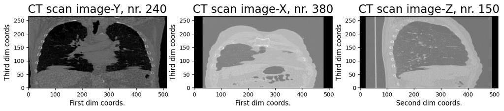

```python
img_viz = nib.load(ind1)
img_viz_data = img_viz.get_fdata()

fig, ax = plt.subplots(ncols=3, figsize=(15, 5))

ax[0].imshow(img_viz_data[:, 240, :].T, origin='lower', cmap='gray')
ax[0].set_xlabel('First dim coords.', fontsize=12)
ax[0].set_ylabel('Third dim coords', fontsize=12)
ax[0].set_title('CT scan image-Y, nr. 240', fontsize=20)


ax[1].imshow(img_viz_data[:, 380, :].T, origin='lower', cmap='gray')
ax[1].set_xlabel('First dim coords.', fontsize=12)
ax[1].set_ylabel('Third dim coords', fontsize=12)
ax[1].set_title('CT scan image-X, nr. 380', fontsize=20)


ax[2].imshow(img_viz_data[150, :, :].T, origin='lower', cmap='gray')
ax[2].set_xlabel('Second dim coords.', fontsize=12)
ax[2].set_ylabel('Third dim coords', fontsize=12)
ax[2].set_title('CT scan image-Z, nr. 150', fontsize=20)
```

We do the same with the second image (img2):

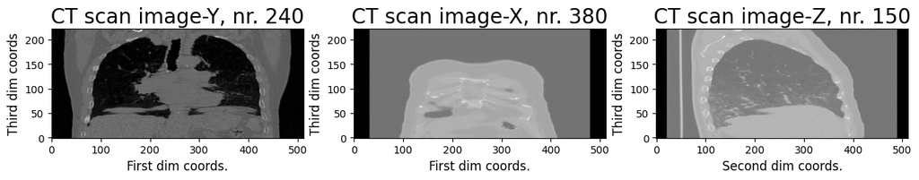

```python
img_vizz = nib.load(ind2)
img_vizz_data = img_vizz.get_fdata()

fig, ax = plt.subplots(ncols=3, figsize=(15, 5))

ax[0].imshow(img_vizz_data[:, 240, :].T, origin='lower', cmap='gray')
ax[0].set_xlabel('First dim coords.', fontsize=12)
ax[0].set_ylabel('Third dim coords', fontsize=12)
ax[0].set_title('CT scan image-Y, nr. 240', fontsize=20)


ax[1].imshow(img_vizz_data[:, 380, :].T, origin='lower', cmap='gray')
ax[1].set_xlabel('First dim coords.', fontsize=12)
ax[1].set_ylabel('Third dim coords', fontsize=12)
ax[1].set_title('CT scan image-X, nr. 380', fontsize=20)


ax[2].imshow(img_vizz_data[150, :, :].T, origin='lower', cmap='gray')
ax[2].set_xlabel('Second dim coords.', fontsize=12)
ax[2].set_ylabel('Third dim coords', fontsize=12)
ax[2].set_title('CT scan image-Z, nr. 150', fontsize=20)
```

## Segmentation of the images

Later we are going to apply segmentation to get the masks from the CT scan images. We will get the segmentation with the following command:

```python
from lungmask import mask
segmentation = mask.apply(img1)
segmentation.shape
```

```
INFO:root:No GPU support available, will use CPU. Note, that this is significantly slower!
```

```
(266, 512, 512)
```

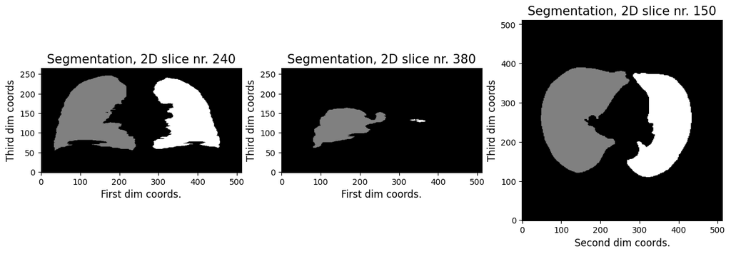

```python
fig, ax = plt.subplots(ncols=3, figsize=(15, 5))

ax[0].imshow(segmentation[:, 240, :], origin='lower', cmap='gray')
ax[0].set_xlabel('First dim coords.', fontsize=12)
ax[0].set_ylabel('Third dim coords', fontsize=12)
ax[0].set_title('Segmentation, 2D slice nr. 240', fontsize=15)


ax[1].imshow(segmentation[:, 380, :], origin='lower', cmap='gray')
ax[1].set_xlabel('First dim coords.', fontsize=12)
ax[1].set_ylabel('Third dim coords', fontsize=12)
ax[1].set_title('Segmentation, 2D slice nr. 380', fontsize=15)


ax[2].imshow(segmentation[150, :, :], origin='lower', cmap='gray')
ax[2].set_xlabel('Second dim coords.', fontsize=12)
ax[2].set_ylabel('Third dim coords', fontsize=12)
ax[2].set_title('Segmentation, 2D slice nr. 150', fontsize=15)
```

Same for the second image:

```python
segmentation2 = mask.apply(img2)
segmentation2.shape
```

```
INFO:root:No GPU support available, will use CPU. Note, that this is significantly slower!
```

```
(222, 512, 512)
```

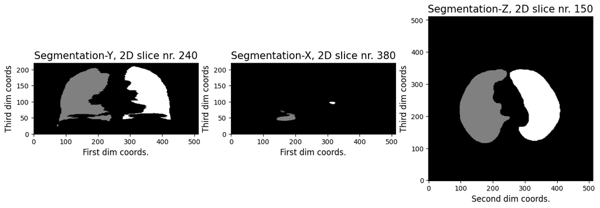

```python
fig, ax = plt.subplots(ncols=3, figsize=(15, 5))

ax[0].imshow(segmentation2[:, 240, :], origin='lower', cmap='gray')
ax[0].set_xlabel('First dim coords.', fontsize=12)
ax[0].set_ylabel('Third dim coords', fontsize=12)
ax[0].set_title('Segmentation-Y, 2D slice nr. 240', fontsize=15)


ax[1].imshow(segmentation2[:, 380, :], origin='lower', cmap='gray')
ax[1].set_xlabel('First dim coords.', fontsize=12)
ax[1].set_ylabel('Third dim coords', fontsize=12)
ax[1].set_title('Segmentation-X, 2D slice nr. 380', fontsize=15)


ax[2].imshow(segmentation2[150, :, :], origin='lower', cmap='gray')
ax[2].set_xlabel('Second dim coords.', fontsize=12)
ax[2].set_ylabel('Third dim coords', fontsize=12)
ax[2].set_title('Segmentation-Z, 2D slice nr. 150', fontsize=15)
```

### 2) Get the mask form the segmentation

Now we are going the get the binary image of the segmentation, only 2 colors on the image (black and white). To get that we use the following command: segmentation[segmentation > 0] = 1 Meaning that black pixels are represented by 0 (false) and white ones by 1 (true). Therefore the white pixels are going to dispose the region of interest in our images that are, obviously, the lungs.

Then we are going to show the results on the first and second image.

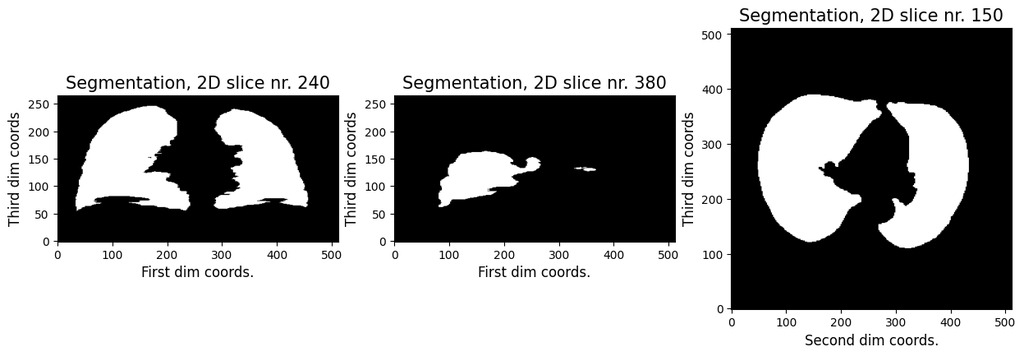

```python
segmentation[segmentation > 0] = 1

fig, ax = plt.subplots(ncols=3, figsize=(15, 5))

ax[0].imshow(segmentation[:, 240, :], origin='lower', cmap='gray')
ax[0].set_xlabel('First dim coords.', fontsize=12)
ax[0].set_ylabel('Third dim coords', fontsize=12)
ax[0].set_title('Segmentation, 2D slice nr. 240', fontsize=15)


ax[1].imshow(segmentation[:, 380, :], origin='lower', cmap='gray')
ax[1].set_xlabel('First dim coords.', fontsize=12)
ax[1].set_ylabel('Third dim coords', fontsize=12)
ax[1].set_title('Segmentation, 2D slice nr. 380', fontsize=15)


ax[2].imshow(segmentation[150, :, :], origin='lower', cmap='gray')
ax[2].set_xlabel('Second dim coords.', fontsize=12)
ax[2].set_ylabel('Third dim coords', fontsize=12)
ax[2].set_title('Segmentation, 2D slice nr. 150', fontsize=15)
```

To obtain the final segmented image, we will create an overlay of the binary image and the original CT imaging. In this way, only the lungs will be displayed in the images, so that the information to be analyzed will be reduced to only the significant data.

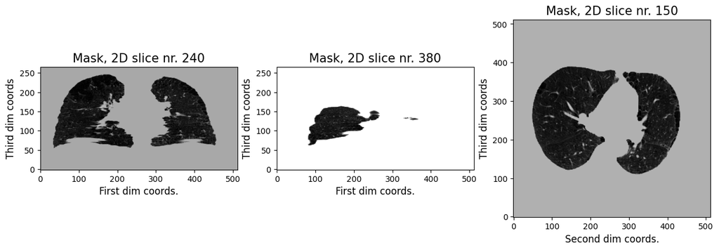

```python
if img1.GetSize()[2] > 1:
    masked_img1 = np.zeros((img1.GetSize()[2], img1.GetSize()[0], img1.GetSize()[1]))
    for i in range(1, segmentation.__len__()):
        masked_img1[i,:,:] = np.where(segmentation[i,:,:] == 1, sitk.GetArrayFromImage(img1)[i,:,:], 0)
else:
    masked_img1 = np.where(segmentation == 1, sitk.GetArrayFromImage(img1)[0,:,:], 0)
    masked_img1 = masked_img1[0,:,:]
    segmentation = segmentation[0,:,:]


fig, ax = plt.subplots(ncols=3, figsize=(15, 5))

ax[0].imshow(masked_img1[:, 240, :], origin='lower', cmap='gray')
ax[0].set_xlabel('First dim coords.', fontsize=12)
ax[0].set_ylabel('Third dim coords', fontsize=12)
ax[0].set_title('Mask, 2D slice nr. 240', fontsize=15)


ax[1].imshow(masked_img1[:, 380, :], origin='lower', cmap='gray')
ax[1].set_xlabel('First dim coords.', fontsize=12)
ax[1].set_ylabel('Third dim coords', fontsize=12)
ax[1].set_title('Mask, 2D slice nr. 380', fontsize=15)


ax[2].imshow(masked_img1[150, :, :], origin='lower', cmap='gray')
ax[2].set_xlabel('Second dim coords.', fontsize=12)
ax[2].set_ylabel('Third dim coords', fontsize=12)
ax[2].set_title('Mask, 2D slice nr. 150', fontsize=15)
```

We repeat the exact same process for the second image.

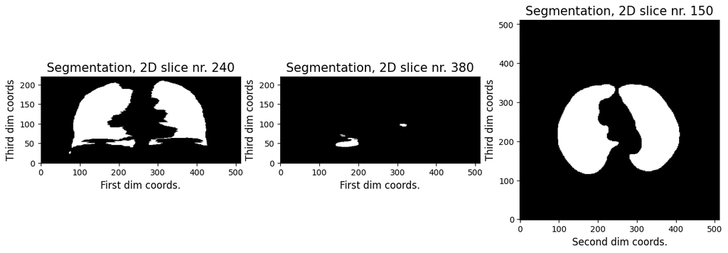

```python
segmentation2[segmentation2 > 0] = 1

fig, ax = plt.subplots(ncols=3, figsize=(15, 5))

ax[0].imshow(segmentation2[:, 240, :], origin='lower', cmap='gray')
ax[0].set_xlabel('First dim coords.', fontsize=12)
ax[0].set_ylabel('Third dim coords', fontsize=12)
ax[0].set_title('Segmentation, 2D slice nr. 240', fontsize=15)


ax[1].imshow(segmentation2[:, 380, :], origin='lower', cmap='gray')
ax[1].set_xlabel('First dim coords.', fontsize=12)
ax[1].set_ylabel('Third dim coords', fontsize=12)
ax[1].set_title('Segmentation, 2D slice nr. 380', fontsize=15)


ax[2].imshow(segmentation2[150, :, :], origin='lower', cmap='gray')
ax[2].set_xlabel('Second dim coords.', fontsize=12)
ax[2].set_ylabel('Third dim coords', fontsize=12)
ax[2].set_title('Segmentation, 2D slice nr. 150', fontsize=15)
```

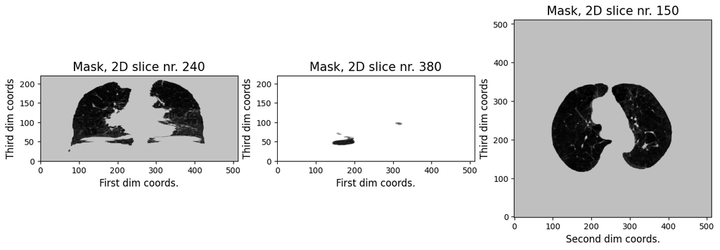

```python
if img2.GetSize()[2] > 1:
    masked_img2 = np.zeros((img2.GetSize()[2], img2.GetSize()[0], img2.GetSize()[1]))
    for i in range(1, segmentation2.__len__()):
        masked_img2[i,:,:] = np.where(segmentation2[i,:,:] == 1, sitk.GetArrayFromImage(img2)[i,:,:], 0)
else:
    masked_img2 = np.where(segmentation == 1, sitk.GetArrayFromImage(img2)[0,:,:], 0)
    masked_img2 = masked_img2[0,:,:]
    segmentation2 = segmentation2[0,:,:]


fig, ax = plt.subplots(ncols=3, figsize=(15, 5))

ax[0].imshow(masked_img2[:, 240, :], origin='lower', cmap='gray')
ax[0].set_xlabel('First dim coords.', fontsize=12)
ax[0].set_ylabel('Third dim coords', fontsize=12)
ax[0].set_title('Mask, 2D slice nr. 240', fontsize=15)


ax[1].imshow(masked_img2[:, 380, :], origin='lower', cmap='gray')
ax[1].set_xlabel('First dim coords.', fontsize=12)
ax[1].set_ylabel('Third dim coords', fontsize=12)
ax[1].set_title('Mask, 2D slice nr. 380', fontsize=15)


ax[2].imshow(masked_img2[150, :, :], origin='lower', cmap='gray')
ax[2].set_xlabel('Second dim coords.', fontsize=12)
ax[2].set_ylabel('Third dim coords', fontsize=12)
ax[2].set_title('Mask, 2D slice nr. 150', fontsize=15)
```

### 3) Saving the segmentation images

For the final step of the segmentation process we save the images by using the following command:

First image:

```python
segmentation = sitk.GetImageFromArray(segmentation)
segmentation.CopyInformation(img1)
sitk.WriteImage(segmentation, ind1[:-7] + '_mask.nii.gz')
```

Second image:

```python
segmentation2 = sitk.GetImageFromArray(segmentation2)
segmentation2.CopyInformation(img2)
sitk.WriteImage(segmentation2, ind2[:-7] + '_mask.nii.gz')
```

## Feature extraction

Feature extraction refers to the process of transforming raw data into numerical features that can be processed while preserving the information in the original data set.

[figure not shown]

Reference: https://www.sciencedirect.com/topics/computer-science/feature-extraction-network

### Radiomic features

Radiomics refers to the extraction of mineable data from medical imaging. Extracted features typically describe the distribution of signal intensities and spatial relationship of pixels within a region of interest.

For this next step we are going to import some packages to the script, the new ones are:

1. Featureextraxtor from radiomics -> Pyradiomics is an open-source python package for the extraction of Radiomic features from medical imaging, and it can also be used on RStudio.
2. CSV -> Reads and writes comma-separated values (CSV) files.
3. Pandas -> Is a Python package providing fast, flexible, and expressive data structures designed to make working with “relational” or “labeled” data both easy and intuitive.
4. Glob -> (short for global) Is used to return all file paths that match a specific pattern.
5. Joblib -> Is a set of tools to provide lightweight pipelining in Python.

```python
from radiomics import featureextractor
import csv
import pandas as pd
import glob
from joblib import Parallel, delayed
```

Just in case we've forgot we search for the name of the path that we are currently working:

```python
current_path = os.getcwd()
current_path
```

```
'C:\\Users\\Usuario\\Documents\\Pyradiomics'
```

And now we are going to start the process to obtain the radiomic features of the images.

First, we'll need to create a function to embody the feature extractor:

```python
path_to_parameters = "C:/Users/Usuario/Documents/Pyradiomics/Params_fast.yaml"
def inizialize_extractor(path_to_parameters):
    return featureextractor.RadiomicsFeatureExtractor(path_to_parameters)
extractor = inizialize_extractor(path_to_parameters)
```

```
INFO:radiomics.featureextractor:Loading parameter file C:/Users/Usuario/Documents/Pyradiomics/Params_fast.yaml
INFO:pykwalify.core:validation.valid
```

Defining the function to print the features that will be calculated later on:

```python
def print_enabled_features(extractor):
    radiomic_features = list(extractor.enabledFeatures.keys())
    d = {'Enabled features': radiomic_features}
    print(pd.DataFrame(d))
print_enabled_features(extractor)
```

```
  Enabled features
0       firstorder
```

Defining the fucntion to print the settings defined to the extractor:

```python
def print_extractor_settings(extractor):
    settings, values = list(extractor.settings.keys()), list(extractor.settings.values())
    d = {'Settings': settings, 'Values': values}
    print(pd.DataFrame(d))
print_extractor_settings(extractor)
```

```
                 Settings       Values
0    minimumROIDimensions            3
1          minimumROISize         None
2               normalize        False
3          normalizeScale            1
4          removeOutliers         None
5   resampledPixelSpacing    [1, 1, 1]
6            interpolator  sitkBSpline
7                 preCrop        False
8             padDistance            5
9               distances          [1]
10                force2D        False
11       force2Ddimension            0
12         resegmentRange         None
13                  label            1
14         additionalInfo         True
15               binWidth           25
16          weightingNorm         None
17            correctMask         True
```

Then we are going to define the function to create a list of patients ids. This command will search the raw images, not the masks that we have generated before, from our document files (path_to_patients) and create a list of patients as an output.

```python
path_to_patients = "C:/Users/Usuario/Documents/Pyradiomics/images"
def list_patients(path_to_patients):
    #return os.listdir(path_to_patients)
    return glob.glob(path_to_patients + "/*STD*[!mask].nii.gz")
list_patients(path_to_patients)
```

```
['C:/Users/Usuario/Documents/Pyradiomics/images\\026658004000_INSP_STD_L1_ECLIPSE.nii.gz',
 'C:/Users/Usuario/Documents/Pyradiomics/images\\026658006358_INSP_STD_L1_ECLIPSE.nii.gz']
```

Function to get the original image and the mask

```python
def get_image_mask(patient, path_to_patients):
    path_original = path_to_patients + '/' + patient
    path_mask = path_to_patients + '/' + patient[:-7] + '_mask.nii.gz'
    if os.path.exists(path_mask):
      return path_original, path_mask
    else:
      print('Patient ',patient,'missing image or mask')
      return False
```

```python
# Function to calculate the radiomic features of a patient
def calculate_radiomic_features(extractor, path_to_original_image, path_to_mask):
    return extractor.execute(path_to_original_image, path_to_mask)
```

```python
# Function to save radiomic extraction results to a .tsv
def save_results(result, path_to_output_dir, patient):
    path_to_output_file = path_to_output_dir + '/' + patient + '.tsv'

# Storing the radiomic features in the .tsv file
    with open(path_to_output_file, "w") as outfile:
        # Create the .tsv file
        csvwriter = csv.writer(outfile, delimiter='\t')

        # Iteration over all the values and keys of the extraction results
        for key, value in result.items():
            obj_to_write = []
            obj_to_write.append(str(key))
            obj_to_write.append(str(value))
            csvwriter.writerow(obj_to_write)
    sentence = str('Successful radiomic extraction for patient:\t' + patient)
    print(sentence)
```

```python
# Function to merge all .tsv into a unique .tsv file for all patients
def merge_tsv_files(general_file, input_file, patient_id):
    df_general = pd.read_csv(general_file,header=None, sep='\t')
    df_input = pd.read_csv(input_file, header=None, sep='\t')

    df_general[patient_id] = df_input[1]

    df_general.to_csv(general_file, header=None, index=False, sep='\t')
```

```python
# Function to generate a unique file with the radiomic features of all the patients
def generate_final_file(results, path_to_output_dir):
    path_to_final_file = path_to_output_dir + '/failed_patients.tsv'
    res = pd.DataFrame(results)
    res.to_csv(path_to_final_file , header=None, index=False, sep='\t')
```

```python
# Function to print the summary of the process
def print_summary(id_list, path_to_output_dir):
    print('Radiomic features extraction have been finished')

    if len(id_list) == 0:
        print('All patients could be processed')

    else:
        print('All patients but ', len(id_list), ' were processed. The following ids correspond to the patients that may have some issues in the NIFTI input files')
        id_str = '\n'.join(id_list)
        path_to_issues_report = path_to_output_dir + '/issues_report.txt'
        with open(path_to_issues_report, "w") as issues:
            issues.write("IDs of the patients that could not be processed:\n")
            issues.write(id_str)
```

```python
# Final function
def Radiomic_features(path_to_patients, path_to_output,
                                path_to_parameters):

    # Instatntiate the extractor
    extractor = inizialize_extractor(path_to_parameters)
    print('Instatntiate the extractor: Done\n')

    # Print enabled parameters
    print_enabled_features(extractor)
    print('Print enabled parameters: Done\n')

    # Print settings and its corresponding values
    print_extractor_settings(extractor)
    print('Print settings and its corresponding values: Done\n')

    # Creation of a patients id list
    patients_id_list = list_patients(path_to_patients)
    print('Creation of a patients id list: Done\n')

    # Iteration over all patients to calculate their radiomic features
    #for patient in patients_id_list:
    #   patient = os.path.basename(patient)
    #   try:
    #       # Get path to image and mask file
    #       image, mask = get_image_mask(patient, path_to_patients)
    #       print('image:', image, '\nmask:', mask)
    #
    #       # Calculate radiomic features
    #       result = calculate_radiomic_features(extractor, image, mask)
    #       print('\nRadiomic features claculated for patient:',patient)
    #       # Save radiomic features of the patient to a .tsv file
    #        save_results(result, path_to_output, patient)
    #
    #        # Append patient id to the processed patients list
    #        patients_processed.append(patient)
    #
    #    except:
    #        patients_with_error.append(patient)
    #        print('\nError occurred for patient:', patient)

    def parallelized_get_features(patient):
        patient = os.path.basename(patient)
        try:
            # Get path to image and mask file
            image, mask = get_image_mask(patient, path_to_patients)
            print('image:', image, '\nmask:', mask)

            # Calculate radiomic features
            result = calculate_radiomic_features(extractor, image, mask)
            print('\nRadiomic features claculated for patient:',patient)
            # Save radiomic features of the patient to a .tsv file
            save_results(result, path_to_output, patient)

        except:
            print('\nError occurred for patient:', patient)
            return patient


    results = Parallel(n_jobs=1)(delayed(parallelized_get_features)(i) for i in patients_id_list)
    results = [i for i in results if i]
    # Create the final .tsv with the radiomic features of all patients
    generate_final_file(results, path_to_output)

    # print_summary(patients_with_error, path_to_output)
```

```python
Radiomic_features(path_to_patients,
                  "C:/Users/Usuario/Documents/Pyradiomics/results/",
                  path_to_parameters)
```

```
INFO:radiomics.featureextractor:Loading parameter file C:/Users/Usuario/Documents/Pyradiomics/Params_fast.yaml
INFO:pykwalify.core:validation.valid
Instatntiate the extractor: Done

  Enabled features
0       firstorder
Print enabled parameters: Done

                 Settings       Values
0    minimumROIDimensions            3
1          minimumROISize         None
2               normalize        False
3          normalizeScale            1
4          removeOutliers         None
5   resampledPixelSpacing    [1, 1, 1]
6            interpolator  sitkBSpline
7                 preCrop        False
8             padDistance            5
9               distances          [1]
10                force2D        False
11       force2Ddimension            0
12         resegmentRange         None
13                  label            1
14         additionalInfo         True
15               binWidth           25
16          weightingNorm         None
17            correctMask         True
Print settings and its corresponding values: Done

Creation of a patients id list: Done

image: C:/Users/Usuario/Documents/Pyradiomics/images/026658004000_INSP_STD_L1_ECLIPSE.nii.gz
mask: C:/Users/Usuario/Documents/Pyradiomics/images/026658004000_INSP_STD_L1_ECLIPSE_mask.nii.gz
INFO:radiomics.featureextractor:Calculating features with label: 1
INFO:radiomics.featureextractor:Loading image and mask
INFO:radiomics.imageoperations:Applying resampling from spacing [0.71093798 0.71093798 1.25      ] and size [512 512 222] to spacing [1. 1. 1.] and size [265, 213, 257]
INFO:radiomics.featureextractor:Adding image type "Original" with custom settings: {}
INFO:radiomics.featureextractor:Adding image type "LoG" with custom settings: {'sigma': [1.0, 2.0, 3.0, 4.0, 5.0]}
INFO:radiomics.featureextractor:Adding image type "Wavelet" with custom settings: {}
INFO:radiomics.featureextractor:Calculating features for original image
```

[output cut: 78 more lines]

[output not shown]